# Autocallables: Computing Expected Life

## Quick Refresher on markov Modeling

| Concept | Definition | Key criterion / formula | In the autocallable chain | |---|---|---|---| | **State space** | The set of all possible values $X_n$ can take | — | $\{A_1,A_2,A_3,A_4,C_1,C_2,C_3,M_H,M_M,M_L\}$ | | **Transition matrix $P$** | Row-stochastic: $P_{ij}=P(X_{n+1}=j\mid X_n=i)$ | every entry $\ge0$, $\sum_j P_{ij}=1$ | each row of $[Q\ R]$ sums to 1 by construction | | **Transient state** | Visited only finitely many times a.s.; probability of return $<1$ | $\sum_n P^{(n)}_{ii}<\infty$ | $A_1,A_2,A_3,A_4$ | | **Absorbing state** | Special case of recurrent: once entered, never left | $P_{ii}=1$ | $C_1,C_2,C_3,M_H,M_M,M_L$ | | **Recurrent state** | Probability of eventual return $=1$ | $\sum_n P^{(n)}_{ii}=\infty$ | none of the *non-absorbing* states are recurrent — that's what makes the chain absorbing | | **Communicating class** | Maximal set of states all mutually reachable | $i\leftrightarrow j$ | each $A_n$ and each absorbing state is its own singleton class — no two-way communication | | **Irreducibility** | Single communicating class; every state reachable from every other | — | **fails by design** — once absorbed, you can't reach a transient state again | | **Periodicity** | $\gcd$ of return times to a state | $d(i)=\gcd\{n: P^{(n)}_{ii}>0\}$ | not meaningful here — transient states are never revisited, absorbing states are period 1 (self-loop) | | **Ergodicity** | Irreducible + aperiodic + positive recurrent $\Rightarrow$ unique stationary $\pi$, time-avg = ensemble-avg | requires irreducibility | **does not apply** — absorbing chains are never ergodic; long-run behavior is "stuck at an absorbing state," not a stationary mix | | **Stationary distribution $\pi$** | $\pi P=\pi,\ \sum_i\pi_i=1$ | unique only if irreducible & positive recurrent | here, *any* point mass on an absorbing state is stationary — degenerate, not informative | | **Canonical form (absorbing chains)** | Reorder transient states first, absorbing last | $P=\begin{pmatrix}Q&R\\0&I\end{pmatrix}$ | exactly the $Q,R$ split used in the autocallable formulation | | **Fundamental matrix $N$** | Expected visits to transient state $j$ starting from $i$ | $N=(I-Q)^{-1}$, well-defined iff $Q^n\to0$ | $N=I+Q+Q^2+Q^3$ since $Q$ is nilpotent (chain only moves forward) | | **Absorption probabilities** | $P(\text{absorbed in } j \mid \text{start } i)$ | $B=NR$ | gives $P(C_n)=\pi_np_n$, $P(M_H),P(M_M),P(M_L)$ | | **Expected time to absorption** | Expected number of steps before hitting an absorbing state | $t=N\mathbf{1}$ | expected life calculation | | **Chapman–Kolmogorov** | Multi-step transitions compose | $P^{(m+n)}=P^{(m)}P^{(n)}$ | used implicitly when propagating $S_t$'s distribution from one observation date to the next | | **Perron–Frobenius / spectral gap** | For irreducible aperiodic chains, second-largest eigenvalue magnitude sets the mixing rate to $\pi$ | $\lambda_1=1>|\lambda_2|$ | **not relevant** for a finite-horizon absorbing chain — there's no mixing to a stationary distribution to speak of | | **$\pi$** | steady-state distribution | satisties $\pi = \pi\text{P}$| a probability vector where each entry corresponds to the long-term likelihood of the process being in a specific state, regardless of the starting conditions.|

Reference: ORF309 lecture notes, Claude

**Parameters:** maturity 8 months, non-call period 2 months, observations every 2 months, autocall barrier 100%, coupon barrier 70%, maturity barrier 60%.

## Setup

Treat the underlying's level relative to its initial value as the random driver. Since it is observed at discrete dates and (under standard GBM-type modeling) each date's level depends only on the *previous* date's level, the process is Markov by construction.

**Observation dates:** $n = 1,2,3,4$ at $t_n = 2,4,6,8$ months. $n=1,2,3$ are call dates; $n=4$ is maturity.

**Transient states** (not yet absorbed): $A_1, A_2, A_3, A_4$ = "alive, entering observation $n$."

**Absorbing states:** $C_1, C_2, C_3$ (called at observation $n$), and $M_H, M_M, M_L$ (matured: full payout / par-only / capital loss).

## State Diagram

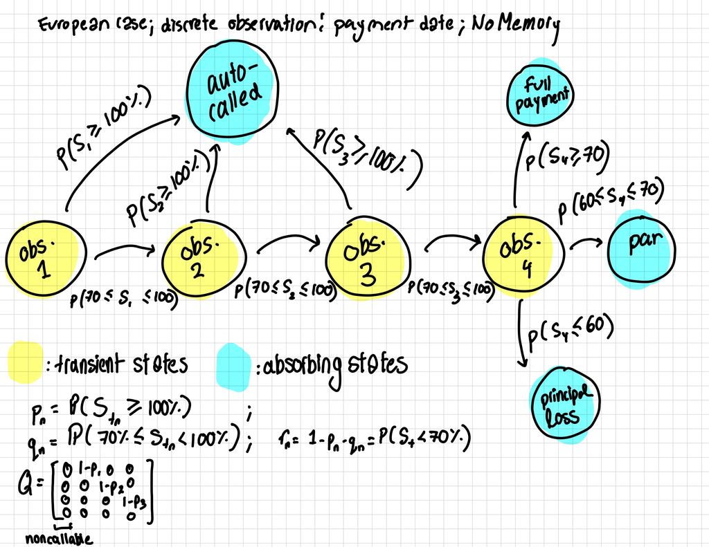

## Canonical form and the fundamental matrix

Order transient states $[A_1,A_2,A_3,A_4]$. Since the chain only moves forward:

$$ Q=\begin{pmatrix}0&1-p_1&0&0\\0&0&1-p_2&0\\0&0&0&1-p_3\\0&0&0&0\end{pmatrix} $$

$Q$ is nilpotent ($Q^4=0$), so the fundamental matrix is exact and finite:

$$ N=(I-Q)^{-1}=I+Q+Q^2+Q^3 $$

$N_{ij}$ = expected number of times the chain occupies transient state $j$, starting from $i$. Because each $A_n$ is visited at most once, $N_{1j}\in\{0,1\}$ along any realized path — it tracks *whether* state $j$ is reached.

## Expected life

$$ E[\text{periods to absorption}] = \sum_{n=1}^{4} n\cdot\pi_n\cdot a_n $$

where $\pi_n=\prod_{k=1}^{n-1}(1-p_k)$ is the probability of reaching observation $n$ (with $\pi_1=1$), and $a_n = p_n$ for $n<4$, $a_4=1$. Explicitly, in months:

$$ E[\text{life}] = t_1 p_1 + t_2(1-p_1)p_2 + t_3(1-p_1)(1-p_2)p_3 + t_4(1-p_1)(1-p_2)(1-p_3) $$

with $t_n \in \{2,4,6,8\}$. This is the expected *redemption date* — the quantity desks call "expected life," since the product rarely actually survives to the stated 8-month maturity once $S$ has a reasonable chance of rallying.

## Absorption probabilities and expected payoff

$B = N R$ gives the absorption probabilities (i.e, the probability that we end up in a specific outcome s.t $B_{ik}=P(\text{end up absorbed in state k∣start in transient state i})$; from $A_1$ these collapse to the simple cascade:

$$ P(C_n)=\pi_n p_n,\qquad P(M_H)=\pi_4 q_H,\quad P(M_M)=\pi_4 q_M,\quad P(M_L)=\pi_4 q_L $$

### Reward structure

This is a Markov chain *with rewards* — coupons attach to transitions, not just terminal states, since a coupon is paid at $t_n$ whenever $S_{t_n}\ge70\%$, whether or not that triggers a call.

| Event | Payoff at $t_n$ |
| --- | --- |
| Called at $n$ ($n\le3$) | Principal + coupon $c$ |
| Continues with coupon ($q_n$, $n\le3$) | $c$ only |
| Continues, no coupon ($r_n$, $n\le3$) | 0 |
| $M_H$ | Principal + coupon $c$ |
| $M_M$ | Principal only |
| $M_L$ | Principal $\times \, S_T/S_0$ |

### Undiscounted expected payoff

$$ E[\text{Payoff}] = \sum_{n=1}^{3}\pi_n\Big[p_n(\text{Principal}+c) + q_n\,c\Big] \;+\; \pi_4\Big[q_H(\text{Principal}+c) + q_M\,\text{Principal} + q_L\,\text{Principal}\cdot E\!\left[\tfrac{S_T}{S_0}\,\Big|\,S_T<60\%\right]\Big] $$

### Present-value (discounted) version

Multiply each $n$-indexed bracket by a discount factor $DF(t_n)$ before summing — this is what you would actually quote as fair value, and it is why expected life matters: it tells you *when*, on average, that PV is realized, which feeds duration/sensitivity analysis even though the PV formula itself does not need the fundamental matrix explicitly.

$$ PV = \sum_{n=1}^{3}\pi_n\,DF(t_n)\Big[p_n(\text{Principal}+c) + q_n\,c\Big] \;+\; \pi_4\,DF(t_4)\Big[q_H(\text{Principal}+c) + q_M\,\text{Principal} + q_L\,\text{Principal}\cdot E\!\left[\tfrac{S_T}{S_0}\,\Big|\,S_T<60\%\right]\Big] $$

## Cmputing $p_n, q_n$

Performing this computation requires $p_n = P(S_{t_n}\ge100\% \mid \text{no autocall at } 1,\dots,n-1)$ — a probability about the *path*, not just the marginal level at $t_n$. Because GBM is Markov, the clean way to compute these probabilities without approximating with unconditional marginals is to **not** collapse "alive" into a single macro-state, but instead run a discretized price-grid Markov chain: a lattice/grid over $S_{t_{n-1}}$, propagate through the lognormal transition kernel to $t_n$, and at each step split the probability mass at the 100% / 70% / 60% boundaries before convolving forward to the next date.